# Análise de Consumo de Álcool entre estudantes da UEFS

#### Análise dos dados obtidos

- É necessária a troca de nome de colunas com caracteres não aceitos pelo R

```r
names(dados_brutos)[3] <- c("FaixaEtaria")
names(dados_brutos)[5] <- c("Trabalha")
names(dados_brutos)[6] <- c("TipoEscola")
names(dados_brutos)[7] <- c("PossuiVeiculo")
names(dados_brutos)[8] <- c("RendaFamiliar")
names(dados_brutos)[9] <- c("MoraComQuem")
names(dados_brutos)[10] <- c("Religiao")
names(dados_brutos)[11] <- c("ImportanteNaVida")
names(dados_brutos)[12] <- c("FamiliaIngere")
names(dados_brutos)[13] <- c("RespondenteIngere")
names(dados_brutos)[14] <- c("IdadeQueComecou")
names(dados_brutos)[15] <- c("QuantosCoposDia")
names(dados_brutos)[16] <- c("Frequencia")
names(dados_brutos)[17] <- c("MotivoDoComecoNoAlcool")
names(dados_brutos)[18] <- c("ImagemQueCausa")
names(dados_brutos)[19] <- c("TipoQueToma")
names(dados_brutos)[20] <- c("DeuVexamePorCausaDaBebida")
names(dados_brutos)[21] <- c("SofreuAcidenteDeCarroPorCausaDaBebida")
names(dados_brutos)[22] <- c("DirigiuSobEfeitoDoAlcool")
names(dados_brutos)[23] <- c("PegouCaronaComAlguemSobEfeitoDaBebida")
names(dados_brutos)[24] <- c("PaisConsomem")
names(dados_brutos)[25] <- c("ConheceAlguemQueSeAcidentouPorCausaDaBebida")
```

- Dados das respostas (SEXO)

```r
# Este bloco SÓ CALCULA e guarda o resultado.
tabela_sexo <- dados_brutos %>%
  count(Sexo, sort = TRUE) %>%
  mutate(
    Percentual = scales::percent(n / sum(n), accuracy = 0.1)
  ) %>%
  rename(
    `Sexo do Respondente` = Sexo,
    Quantidade = n
  )

# Este bloco SÓ APRESENTA a tabela formatada.
knitr::kable(
  tabela_sexo,
  caption = "Distribuição dos respondentes por sexo."
)
```

Distribuição dos respondentes por sexo.

| Sexo do Respondente | Quantidade | Percentual |
| --- | --- | --- |
| Feminino | 36 | 50.7% |
| Masculino | 33 | 46.5% |
| Prefiro não declarar | 2 | 2.8% |

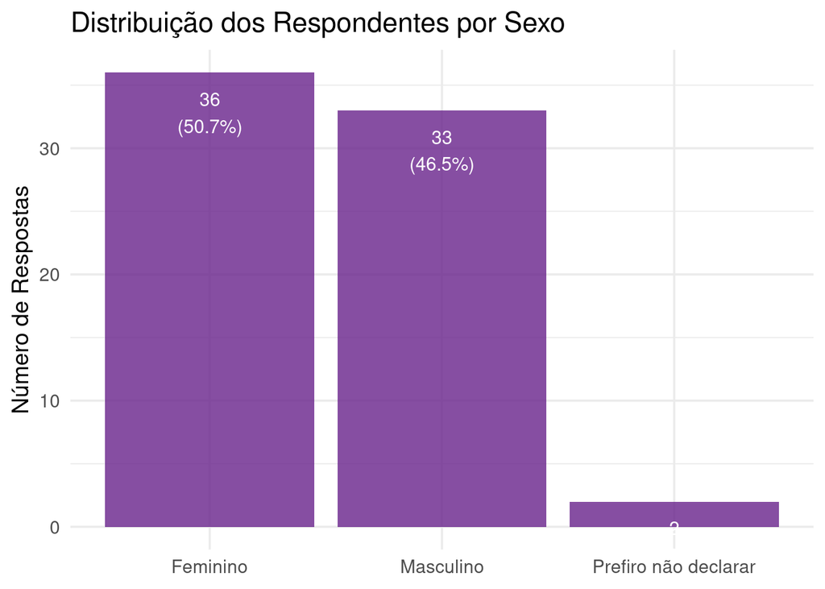

```r
# Este bloco SÓ APRESENTA o gráfico.
ggplot(tabela_sexo, aes(x = reorder(`Sexo do Respondente`, -Quantidade), y = Quantidade)) +
  geom_bar(stat = "identity", fill = "darkorchid4", alpha = 0.8) +
  geom_text(
    aes(label = paste0(Quantidade, "\n(", Percentual, ")")),
    vjust = 1.5,
    color = "white",
    size = 4
  ) +
  labs(
    title = "Distribuição dos Respondentes por Sexo",
    x = NULL,
    y = "Número de Respostas"
  ) +
  theme_minimal(base_size = 14)
```

- Dados das respostas (FAIXA ETÁRIA)

  ```r
  tabela_faixa_etaria <- dados_brutos %>%
    count(FaixaEtaria, sort = TRUE) %>%
    mutate(
      Percentual = scales::percent(n / sum(n), accuracy = 0.1)
    ) %>%
    rename(
      `Faixa etária do Respondente` = FaixaEtaria,
      Quantidade = n
    )

  knitr::kable(
    tabela_faixa_etaria,
    caption = "Distribuição dos respondentes por faixa etária."
  )
  ```

  Distribuição dos respondentes por faixa etária.

  | Faixa etária do Respondente | Quantidade | Percentual |
  | --- | --- | --- |
  | 18 a 20 anos | 31 | 43.7% |
  | 21 a 23 anos | 23 | 32.4% |
  | 24 a 26 anos | 12 | 16.9% |
  | 27 a 29 anos | 4 | 5.6% |
  | Menos de 18 anos | 1 | 1.4% |

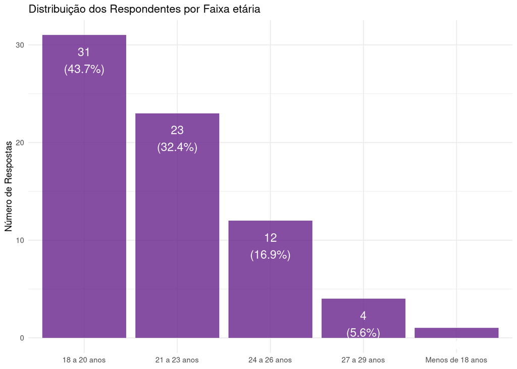

  ```r
  ggplot(tabela_faixa_etaria, aes(x = reorder(`Faixa etária do Respondente`, -Quantidade), y = Quantidade)) +
    geom_bar(stat = "identity", fill = "darkorchid4", alpha = 0.8) +
    geom_text(
      aes(label = paste0(Quantidade, "\n(", Percentual, ")")),
      vjust = 1.5,
      color = "white",
      size = 4
    ) +
    labs(
      title = "Distribuição dos Respondentes por Faixa etária",
      x = NULL,
      y = "Número de Respostas"
    ) +
    theme_minimal(base_size = 9)
  ```

- Dados das respostas (SEMESTRE)

  ```r
  tabela_semestre <- dados_brutos %>%
    count(Semestre, sort = TRUE) %>%
    mutate(
      Percentual = scales::percent(n / sum(n), accuracy = 0.1)
    ) %>%
    rename(
      `Semestre do Respondente` = Semestre,
      Quantidade = n
    )

  knitr::kable(
    tabela_semestre,
    caption = "Semestre do Respondente"
  )
  ```

  Semestre do Respondente

  | Semestre do Respondente | Quantidade | Percentual |
  | --- | --- | --- |
  | 3º semestre | 11 | 15.5% |
  | 6º semestre | 10 | 14.1% |
  | 1º semestre | 9 | 12.7% |
  | 2º semestre | 9 | 12.7% |
  | 4º semestre | 7 | 9.9% |
  | 7º semestre | 7 | 9.9% |
  | 8º semestre | 5 | 7.0% |
  | 5º semestre | 4 | 5.6% |
  | 9º semestre | 4 | 5.6% |
  | 10º semestre | 3 | 4.2% |
  | A partir do 10º semestre | 2 | 2.8% |

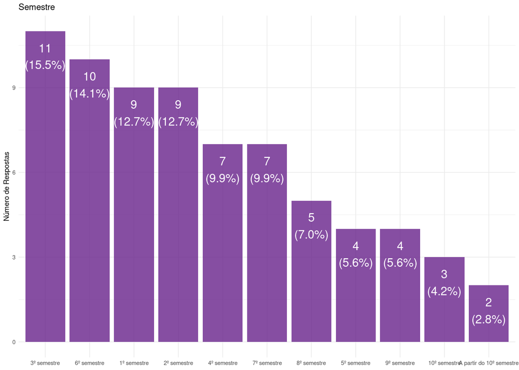

  ```r
  ggplot(tabela_semestre, aes(x = reorder(`Semestre do Respondente`, -Quantidade), y = Quantidade)) +
    geom_bar(stat = "identity", fill = "darkorchid4", alpha = 0.8) +
    geom_text(
      aes(label = paste0(Quantidade, "\n(", Percentual, ")")),
      vjust = 1.5,
      color = "white",
      size = 4
    ) +
    labs(
      title = "Semestre",
      x = NULL,
      y = "Número de Respostas"
    ) +
    theme_minimal(base_size = 7)
  ```

- Dados das respostas (TRABALHO)

  ```r
  tabela_trabalha <- dados_brutos %>%
    count(Trabalha, sort = TRUE) %>%
    mutate(
      Percentual = scales::percent(n / sum(n), accuracy = 0.1)
    ) %>%
    rename(
      `Respondente trabalha?` = Trabalha,
      Quantidade = n
    )

  knitr::kable(
    tabela_trabalha,
    caption = "Respondente trabalha?"
  )
  ```

  Respondente trabalha?

  | Respondente trabalha? | Quantidade | Percentual |
  | --- | --- | --- |
  | Não | 47 | 66.2% |
  | Sim | 24 | 33.8% |

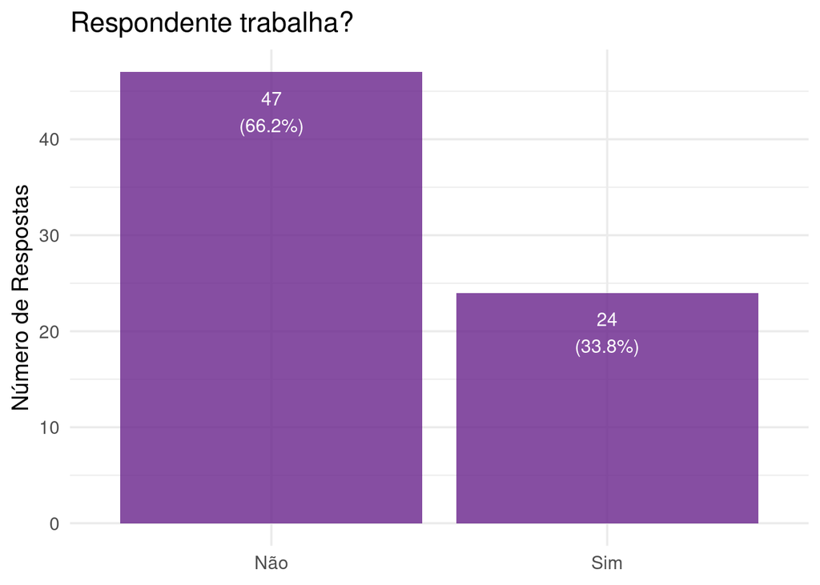

  ```r
  ggplot(tabela_trabalha, aes(x = reorder(`Respondente trabalha?`, -Quantidade), y = Quantidade)) +
    geom_bar(stat = "identity", fill = "darkorchid4", alpha = 0.8) +
    geom_text(
      aes(label = paste0(Quantidade, "\n(", Percentual, ")")),
      vjust = 1.5,
      color = "white",
      size = 4
    ) +
    labs(
      title = "Respondente trabalha?",
      x = NULL,
      y = "Número de Respostas"
    ) +
    theme_minimal(base_size = 14)
  ```

- Dados das respostas (TIPO DE ESCOLA QUE ESTUDOU)

  ```r
  tabela_escola <- dados_brutos %>%
    count(TipoEscola, sort = TRUE) %>%
    mutate(
      Percentual = scales::percent(n / sum(n), accuracy = 0.1)
    ) %>%
    rename(
      `Tipo de escola que estudou?` = TipoEscola,
      Quantidade = n
    )

  knitr::kable(
    tabela_escola,
    caption = "Tipo de escola que estudou?"
  )
  ```

  Tipo de escola que estudou?

  | Tipo de escola que estudou? | Quantidade | Percentual |
  | --- | --- | --- |
  | Pública | 46 | 64.8% |
  | Privada | 25 | 35.2% |

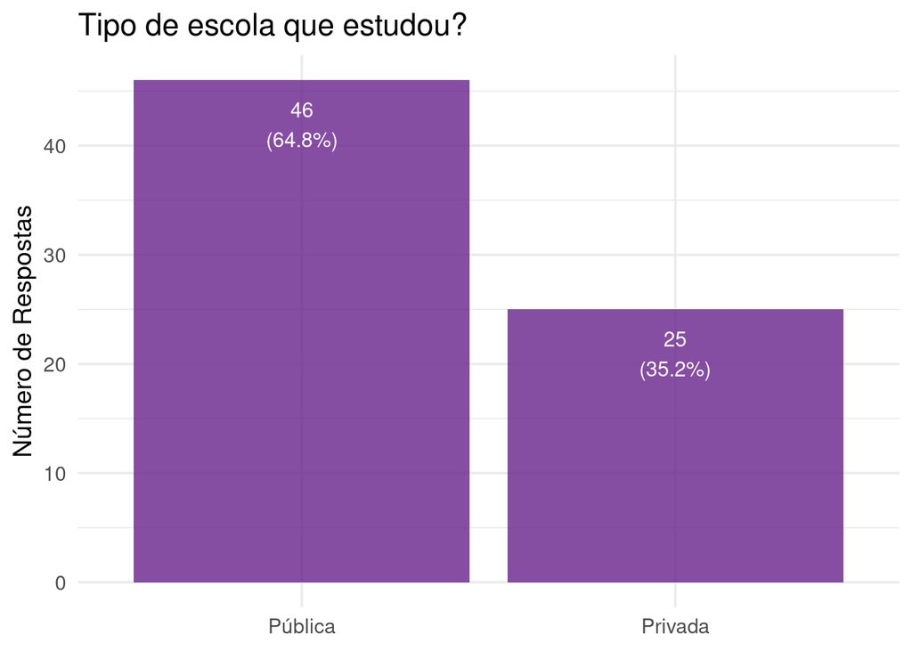

  ```r
  ggplot(tabela_escola, aes(x = reorder(`Tipo de escola que estudou?`, -Quantidade), y = Quantidade)) +
    geom_bar(stat = "identity", fill = "darkorchid4", alpha = 0.8) +
    geom_text(
      aes(label = paste0(Quantidade, "\n(", Percentual, ")")),
      vjust = 1.5,
      color = "white",
      size = 4
    ) +
    labs(
      title = "Tipo de escola que estudou?",
      x = NULL,
      y = "Número de Respostas"
    ) +
    theme_minimal(base_size = 14)
  ```

- Dados das Respostas (POSSUI VEÍCULO)

  ```r
  tabela_veiculo <- dados_brutos %>%
    count(PossuiVeiculo, sort = TRUE) %>%
    mutate(
      Percentual = scales::percent(n / sum(n), accuracy = 0.1)
    ) %>%
    rename(
      `Possui veiculo?` = PossuiVeiculo,
      Quantidade = n
    )

  knitr::kable(
    tabela_veiculo,
    caption = "Possui veiculo?"
  )
  ```

  Possui veiculo?

  | Possui veiculo? | Quantidade | Percentual |
  | --- | --- | --- |
  | Não | 61 | 85.9% |
  | Sim | 10 | 14.1% |

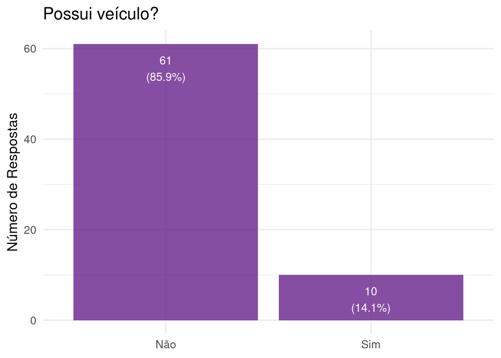

  ```r
  ggplot(tabela_veiculo, aes(x = reorder(`Possui veiculo?`, -Quantidade), y = Quantidade)) +
    geom_bar(stat = "identity", fill = "darkorchid4", alpha = 0.8) +
    geom_text(
      aes(label = paste0(Quantidade, "\n(", Percentual, ")")),
      vjust = 1.5,
      color = "white",
      size = 4
    ) +
    labs(
      title = "Possui veículo?",
      x = NULL,
      y = "Número de Respostas"
    ) +
    theme_minimal(base_size = 14)
  ```

- Dados das respostas (RENDA FAMILIAR)

  ```r
  tabela_renda <- dados_brutos %>%
    count(RendaFamiliar, sort = TRUE) %>%
    mutate(
      Percentual = scales::percent(n / sum(n), accuracy = 0.1)
    ) %>%
    rename(
      `Renda familiar` = RendaFamiliar,
      Quantidade = n
    )

  knitr::kable(
    tabela_renda,
    caption = "Renda familiar"
  )
  ```

  Renda familiar

  | Renda familiar | Quantidade | Percentual |
  | --- | --- | --- |
  | Até 1 salário mínimo | 20 | 28.2% |
  | 1 a 2 salários mínimos | 18 | 25.4% |
  | Prefiro não declarar | 15 | 21.1% |
  | 2 a 4 salários mínimos | 13 | 18.3% |
  | 4 a 6 salários mínimos | 5 | 7.0% |

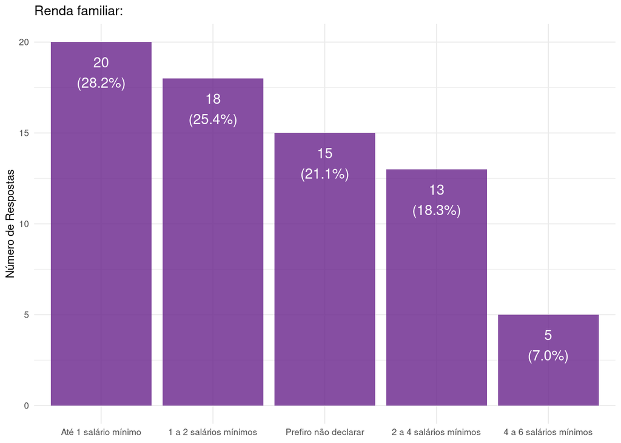

  ```r
  ggplot(tabela_renda, aes(x = reorder(`Renda familiar`, -Quantidade), y = Quantidade)) +
    geom_bar(stat = "identity", fill = "darkorchid4", alpha = 0.8) +
    geom_text(
      aes(label = paste0(Quantidade, "\n(", Percentual, ")")),
      vjust = 1.5,
      color = "white",
      size = 4
    ) +
    labs(
      title = "Renda familiar:",
      x = NULL,
      y = "Número de Respostas"
    ) +
    theme_minimal(base_size = 9)
  ```

- Dados das respostas (MORA COM QUEM?)

  ```r
  tabela_moradia <- dados_brutos %>%
    count(MoraComQuem, sort = TRUE) %>%
    mutate(
      Percentual = scales::percent(n / sum(n), accuracy = 0.1)
    ) %>%
    rename(
      `Mora com quem?` = MoraComQuem,
      Quantidade = n
    )

  knitr::kable(
    tabela_moradia,
    caption = "Mora com quem?"
  )
  ```

  Mora com quem?

  | Mora com quem? | Quantidade | Percentual |
  | --- | --- | --- |
  | Família | 56 | 78.9% |
  | Só | 9 | 12.7% |
  | Amigos | 6 | 8.5% |

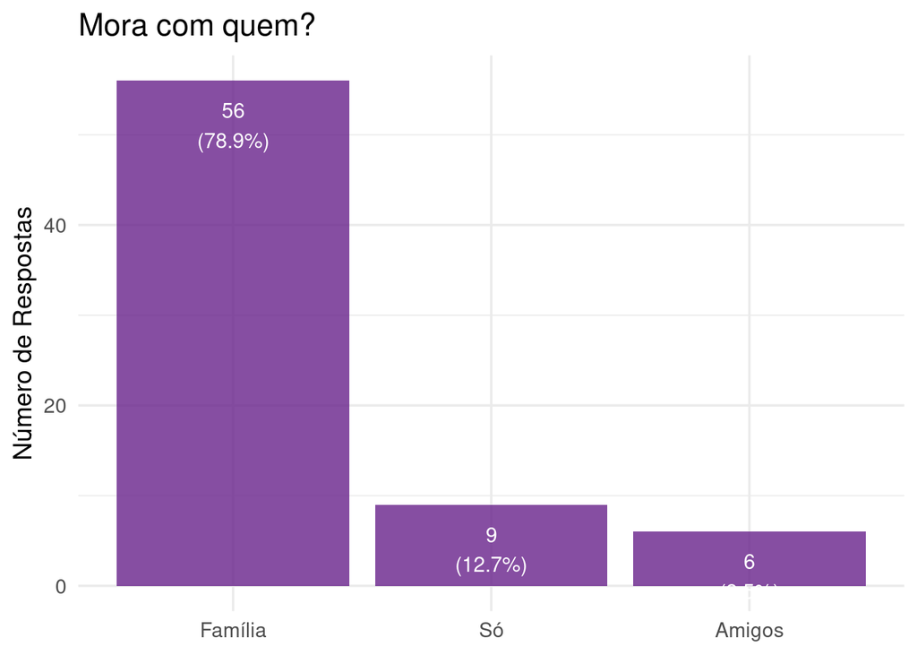

  ```r
  ggplot(tabela_moradia, aes(x = reorder(`Mora com quem?`, -Quantidade), y = Quantidade)) +
    geom_bar(stat = "identity", fill = "darkorchid4", alpha = 0.8) +
    geom_text(
      aes(label = paste0(Quantidade, "\n(", Percentual, ")")),
      vjust = 1.5,
      color = "white",
      size = 4
    ) +
    labs(
      title = "Mora com quem?",
      x = NULL,
      y = "Número de Respostas"
    ) +
    theme_minimal(base_size = 14)
  ```

- Dados das respostas (RELIGIÃO)

  ```r
  tabela_religiao <- dados_brutos %>%
    count(Religiao, sort = TRUE) %>%
    mutate(
      Percentual = scales::percent(n / sum(n), accuracy = 0.1)
    ) %>%
    rename(
      `Religiao` = Religiao,
      Quantidade = n
    )

  knitr::kable(
    tabela_religiao,
    caption = "Religiao"
  )
  ```

  Religiao

  | Religiao | Quantidade | Percentual |
  | --- | --- | --- |
  | Outros | 30 | 42.3% |
  | Católica | 25 | 35.2% |
  | Evangélica | 16 | 22.5% |

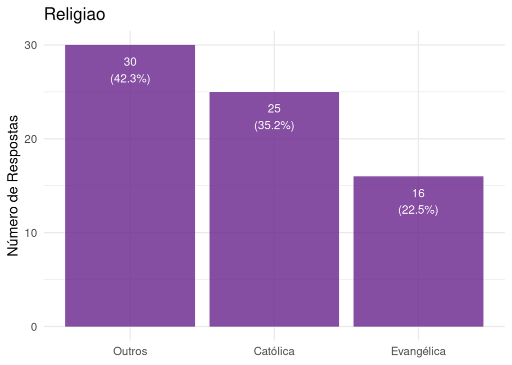

  ```r
  ggplot(tabela_religiao, aes(x = reorder(`Religiao`, -Quantidade), y = Quantidade)) +
    geom_bar(stat = "identity", fill = "darkorchid4", alpha = 0.8) +
    geom_text(
      aes(label = paste0(Quantidade, "\n(", Percentual, ")")),
      vjust = 1.5,
      color = "white",
      size = 4
    ) +
    labs(
      title = "Religiao",
      x = NULL,
      y = "Número de Respostas"
    ) +
    theme_minimal(base_size = 14)
  ```

- Importância do álcool na vida

  ```r
  # 1. CÁLCULO
  tabela_importancia <- dados_brutos %>%
    count(ImportanteNaVida, sort = TRUE) %>%
    mutate(Percentual = scales::percent(n / sum(n), accuracy = 0.1)) %>%
    rename(Resposta = ImportanteNaVida, Quantidade = n)

  # 2. TABELA
  knitr::kable(
    tabela_importancia,
    caption = "A bebida alcoólica é importante na sua vida?"
  )
  ```

  A bebida alcoólica é importante na sua vida?

  | Resposta | Quantidade | Percentual |
  | --- | --- | --- |
  | Não | 67 | 94.4% |
  | Sim | 4 | 5.6% |

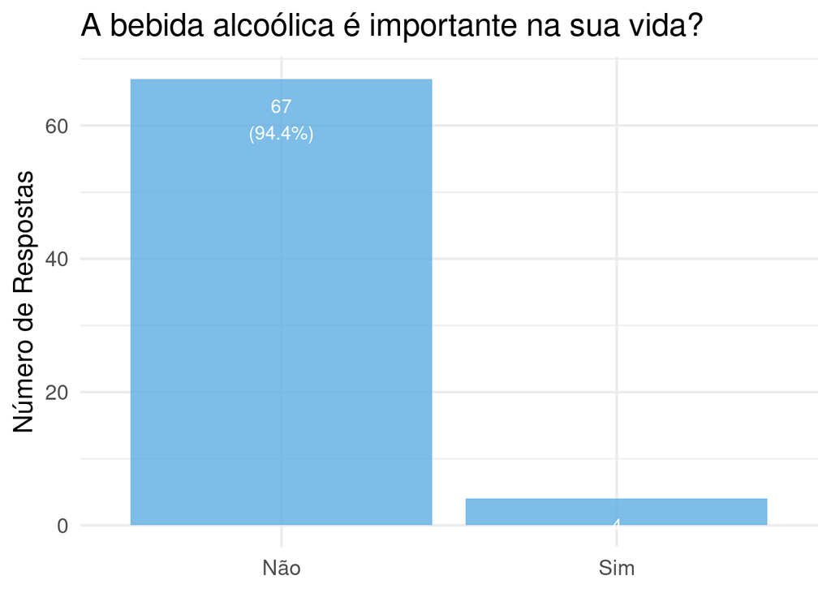

  ```r
  # 3. GRÁFICO
  ggplot(tabela_importancia, aes(x = reorder(Resposta, -Quantidade), y = Quantidade)) +
    geom_bar(stat = "identity", fill = "#5DADE2", alpha = 0.8) +
    geom_text(aes(label = paste0(Quantidade, "\n(", Percentual, ")")), vjust = 1.5, color = "white", size = 4) +
    labs(title = "A bebida alcoólica é importante na sua vida?", x = NULL, y = "Número de Respostas") +
    theme_minimal(base_size = 16)
  ```

- Família ingere bebida alcoólica

  ```r
  # 1. CÁLCULO
  tabela_familia_ingere <- dados_brutos %>%
    count(FamiliaIngere, sort = TRUE) %>%
    mutate(Percentual = scales::percent(n / sum(n), accuracy = 0.1)) %>%
    rename(Resposta = FamiliaIngere, Quantidade = n)

  # 2. TABELA
  knitr::kable(
    tabela_familia_ingere,
    caption = "Na sua família as pessoas tomam bebidas alcoólicas?"
  )
  ```

  Na sua família as pessoas tomam bebidas alcoólicas?

  | Resposta | Quantidade | Percentual |
  | --- | --- | --- |
  | Sim | 57 | 80.3% |
  | Não | 14 | 19.7% |

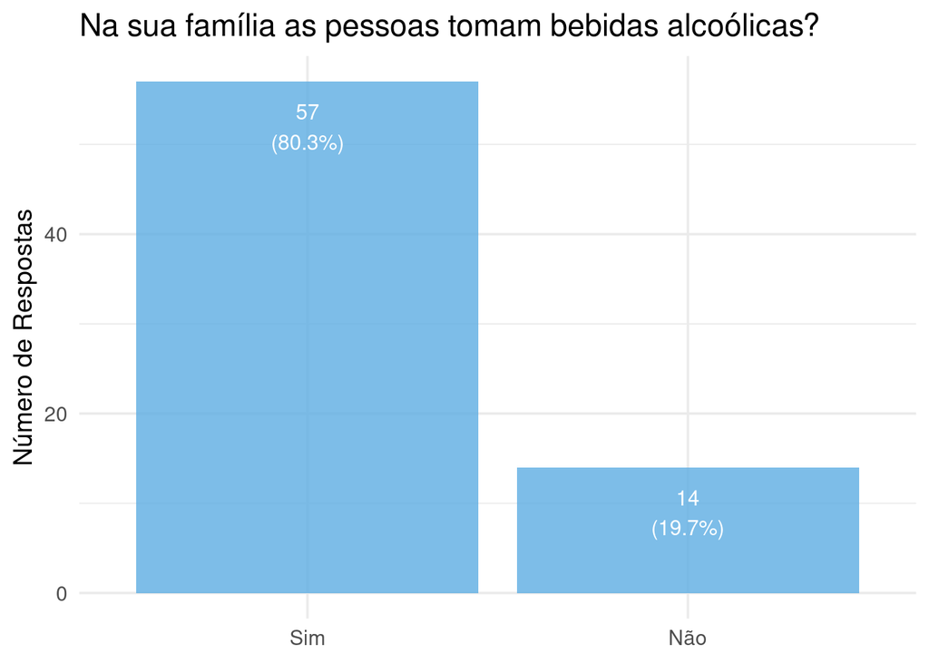

  ```r
  # 3. GRÁFICO
  ggplot(tabela_familia_ingere, aes(x = reorder(Resposta, -Quantidade), y = Quantidade)) +
    geom_bar(stat = "identity", fill = "#5DADE2", alpha = 0.8) +
    geom_text(aes(label = paste0(Quantidade, "\n(", Percentual, ")")), vjust = 1.5, color = "white", size = 4) +
    labs(title = "Na sua família as pessoas tomam bebidas alcoólicas?", x = NULL, y = "Número de Respostas") +
    theme_minimal(base_size = 14)
  ```

- Você ingere?

  ```r
  # 1. CÁLCULO
  tabela_respondente_ingere <- dados_brutos %>%
    count(RespondenteIngere, sort = TRUE) %>%
    mutate(Percentual = scales::percent(n / sum(n), accuracy = 0.1)) %>%
    rename(Resposta = RespondenteIngere, Quantidade = n)

  # 2. TABELA
  knitr::kable(
    tabela_respondente_ingere,
    caption = "Você toma bebidas alcoólicas?"
  )
  ```

  Você toma bebidas alcoólicas?

  | Resposta | Quantidade | Percentual |
  | --- | --- | --- |
  | Não | 39 | 54.9% |
  | Sim | 32 | 45.1% |

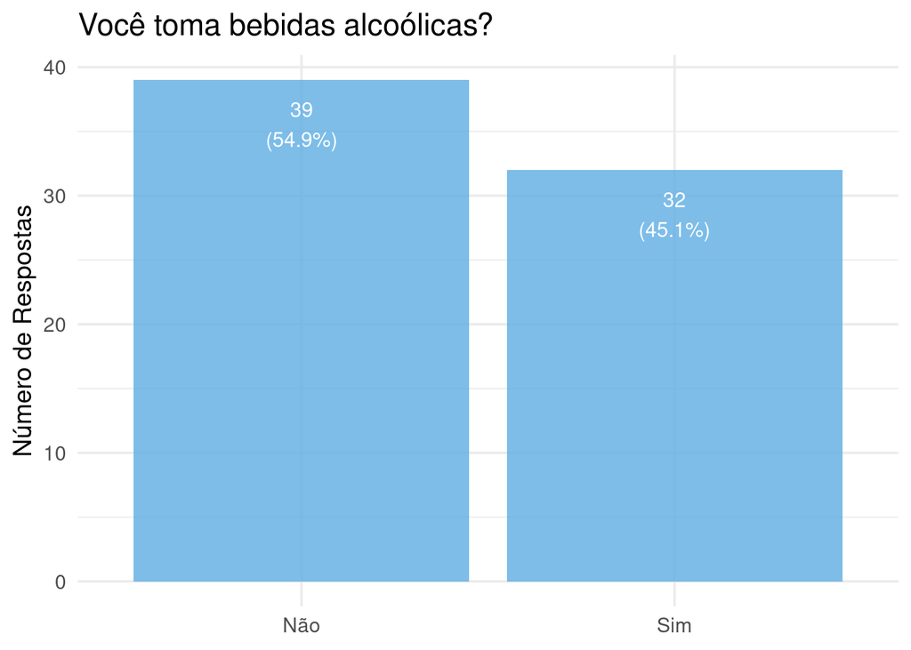

  ```r
  # 3. GRÁFICO
  ggplot(tabela_respondente_ingere, aes(x = reorder(Resposta, -Quantidade), y = Quantidade)) +
    geom_bar(stat = "identity", fill = "#5DADE2", alpha = 0.8) +
    geom_text(aes(label = paste0(Quantidade, "\n(", Percentual, ")")), vjust = 1.5, color = "white", size = 4) +
    labs(title = "Você toma bebidas alcoólicas?", x = NULL, y = "Número de Respostas") +
    theme_minimal(base_size = 14)
  ```

- Idade que começou a consumir

  ```r
  # Este código deve estar no seu bloco de preparação de dados
  niveis_idade_inicio <- c(
    "Menos de 12 anos",
    "12 a 14 anos",
    "15 a 17 anos",
    "18 a 20 anos",
    "21 a 25 anos",
    "Comecei a consumir álcool recentemente (nos últimos 6 meses)",
    "Outra",
    "Não consumo bebidas alcoólicas"
  )

  # Aplica a ordenação ao data frame
  dados_brutos <- dados_brutos %>%
    mutate(IdadeQueComecou = factor(IdadeQueComecou, levels = niveis_idade_inicio))

  # --- Análise Univariada: Idade de Início do Consumo ---

  # 1. CÁLCULO (Seu código aqui está perfeito)
  tabela_idade <- dados_brutos %>%
    count(IdadeQueComecou, sort = TRUE) %>%
    mutate(
      Percentual = scales::percent(n / sum(n), accuracy = 0.1)
    ) %>%
    rename(
      `Idade que comecou` = IdadeQueComecou,
      Quantidade = n
    )

  # 2. TABELA (Seu código aqui está perfeito)
  knitr::kable(
    tabela_idade,
    caption = "Idade que começou a consumir"
  )
  ```

  Idade que começou a consumir

  | Idade que comecou | Quantidade | Percentual |
  | --- | --- | --- |
  | Não consumo bebidas alcoólicas | 37 | 52.1% |
  | 15 a 17 anos | 15 | 21.1% |
  | 18 a 20 anos | 12 | 16.9% |
  | 21 a 25 anos | 4 | 5.6% |
  | 12 a 14 anos | 2 | 2.8% |
  | Comecei a consumir álcool recentemente (nos últimos 6 meses) | 1 | 1.4% |

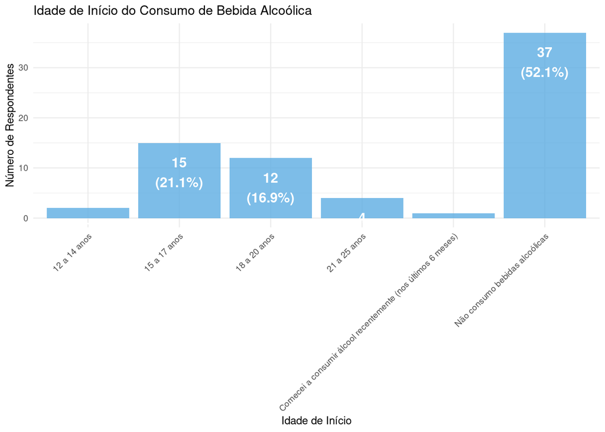

  ```r
  # 3. GRÁFICO (Versão Corrigida)
  ggplot(tabela_idade, aes(x = `Idade que comecou`, y = Quantidade)) + # <-- MUDANÇA 1: reorder() removido
    geom_bar(stat = "identity", fill = "#5DADE2", alpha = 0.8) +
    geom_text(
      aes(label = paste0(Quantidade, "\n(", Percentual, ")")),
      vjust = 1.5,
      color = "white",
      size = 4,
      fontface = "bold"
    ) +
    labs(
      title = "Idade de Início do Consumo de Bebida Alcoólica",
      x = "Idade de Início", # Rótulo do eixo X mais limpo
      y = "Número de Respondentes"
    ) +
    theme_minimal(base_size = 9) +

    # --- MUDANÇA 2: Linha adicionada para girar o texto do eixo X ---
    theme(axis.text.x = element_text(angle = 45, hjust = 1))
  ```

- Quantidade de copos por dia

  ```r
  tabela_copos <- dados_brutos %>%
    count(QuantosCoposDia, sort = TRUE) %>%
    mutate(
      Percentual = scales::percent(n / sum(n), accuracy = 0.1)
    ) %>%
    rename(
      `Consumo Diário` = QuantosCoposDia,
      Quantidade = n
    )

  # 2. TABELA
  knitr::kable(tabela_copos, caption = "Quantos copos por dia?")
  ```

  Quantos copos por dia?

  | Consumo Diário | Quantidade | Percentual |
  | --- | --- | --- |
  | Não consumo bebidas alcoólicas | 40 | 56.3% |
  | Menos de 1 copo por dia | 23 | 32.4% |
  | 1 a 2 copos por dia | 2 | 2.8% |
  | 3 a 4 copos por dia | 2 | 2.8% |
  | 5 a 6 copos por dia | 2 | 2.8% |
  | 7 ou mais copos por dia | 2 | 2.8% |

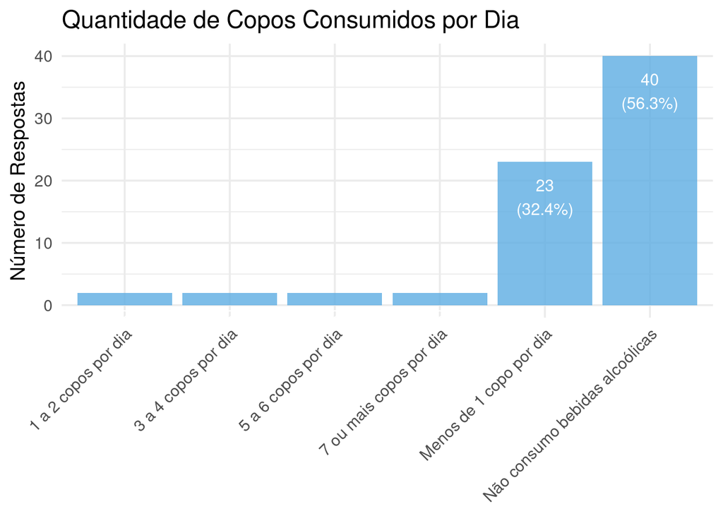

  ```r
  # 3. GRÁFICO
  ggplot(tabela_copos, aes(x = `Consumo Diário`, y = Quantidade)) +
    geom_bar(stat = "identity", fill = "#5DADE2", alpha = 0.8) +
    geom_text(aes(label = paste0(Quantidade, "\n(", Percentual, ")")), vjust = 1.5, color = "white", size = 4) +
    labs(title = "Quantidade de Copos Consumidos por Dia", x = NULL, y = "Número de Respostas") +
    theme_minimal(base_size = 14) +
    theme(axis.text.x = element_text(angle = 45, hjust = 1))
  ```

- Frequência

  ```r
  # 1. CÁLCULO E ORDENAÇÃO
  niveis_frequencia <- c(
    "Fins de semana", "Três vezes ao mês", "Duas vezes ao mês",
    "Só em festas", "Outra", "Não consumo bebidas alcoólicas"
  )

  tabela_frequencia <- dados_brutos %>%
    mutate(Frequencia = factor(Frequencia, levels = niveis_frequencia)) %>%
    count(Frequencia) %>%
    filter(!is.na(Frequencia)) %>%
    mutate(Percentual = scales::percent(n / sum(n), accuracy = 0.1)) %>%
    rename(`Frequência de Consumo` = Frequencia, Quantidade = n)

  # 2. TABELA
  knitr::kable(tabela_frequencia, caption = "Com que frequência?")
  ```

  Com que frequência?

  | Frequência de Consumo | Quantidade | Percentual |
  | --- | --- | --- |
  | Fins de semana | 7 | 9.9% |
  | Duas vezes ao mês | 3 | 4.2% |
  | Só em festas | 21 | 29.6% |
  | Outra | 3 | 4.2% |
  | Não consumo bebidas alcoólicas | 37 | 52.1% |

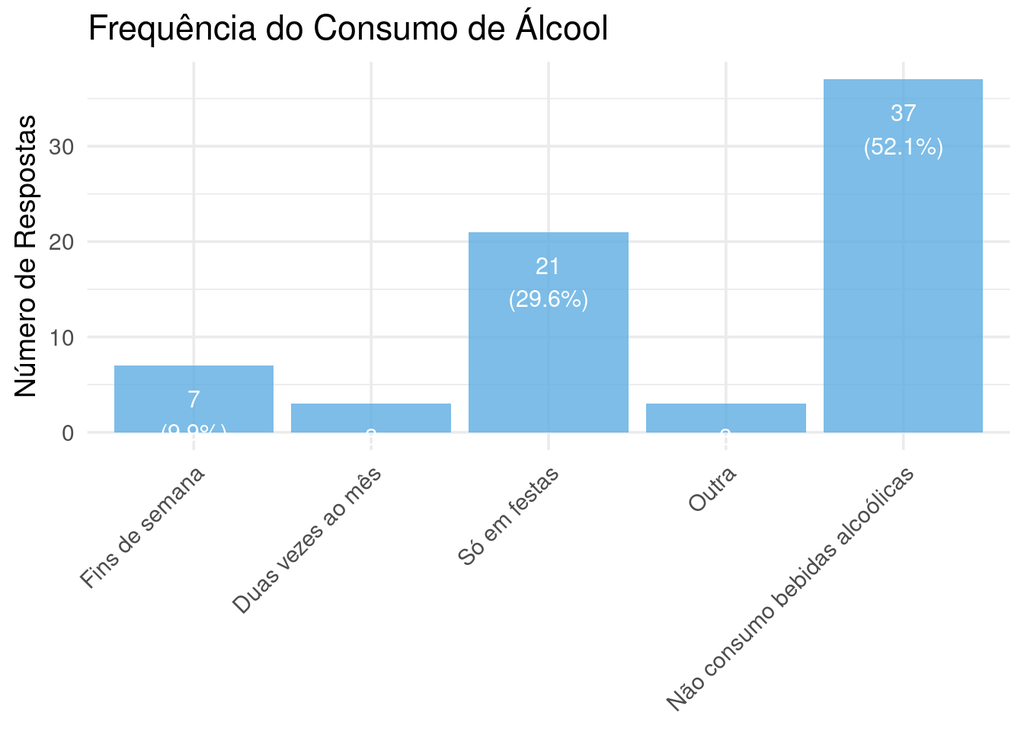

  ```r
  # 3. GRÁFICO
  ggplot(tabela_frequencia, aes(x = `Frequência de Consumo`, y = Quantidade)) +
    geom_bar(stat = "identity", fill = "#5DADE2", alpha = 0.8) +
    geom_text(aes(label = paste0(Quantidade, "\n(", Percentual, ")")), vjust = 1.5, color = "white", size = 4) +
    labs(title = "Frequência do Consumo de Álcool", x = NULL, y = "Número de Respostas") +
    theme_minimal(base_size = 14) +
    theme(axis.text.x = element_text(angle = 45, hjust = 1))
  ```

- Motivo de iniciar o consumo de álcool

  ```r
  # 1. CÁLCULO
  tabela_motivo <- dados_brutos %>%
    count(MotivoDoComecoNoAlcool, sort = TRUE) %>%
    mutate(Percentual = scales::percent(n / sum(n), accuracy = 0.1)) %>%
    rename(Motivo = MotivoDoComecoNoAlcool, Quantidade = n)

  # 2. TABELA
  knitr::kable(tabela_motivo, caption = "Por qual motivo começou a tomar bebida alcoólica?")
  ```

  Por qual motivo começou a tomar bebida alcoólica?

  | Motivo | Quantidade | Percentual |
  | --- | --- | --- |
  | Não consumo bebidas alcoólicas | 36 | 50.7% |
  | Iniciativa própria | 18 | 25.4% |
  | Incentivo de amigos | 11 | 15.5% |
  | Outros motivos | 4 | 5.6% |
  | Incentivo da família | 2 | 2.8% |

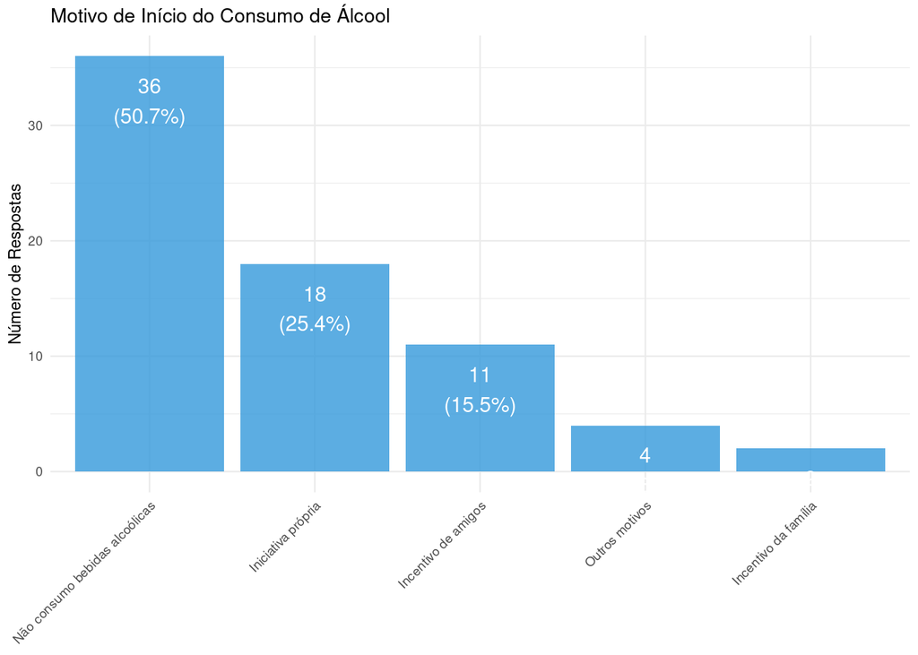

  ```r
  # 3. GRÁFICO
  ggplot(tabela_motivo, aes(x = reorder(Motivo, -Quantidade), y = Quantidade)) +
    geom_bar(stat = "identity", fill = "#3498DB", alpha = 0.8) +
    geom_text(aes(label = paste0(Quantidade, "\n(", Percentual, ")")), vjust = 1.5, color = "white", size = 4) +
    labs(title = "Motivo de Início do Consumo de Álcool", x = NULL, y = "Número de Respostas") +
    theme_minimal(base_size = 9) +
    theme(axis.text.x = element_text(angle = 45, hjust = 1))
  ```

- Imagem que a bebida causa

  ```r
  # 1. CÁLCULO
  tabela_imagem <- dados_brutos %>%
    count(ImagemQueCausa, sort = TRUE) %>%
    mutate(Percentual = scales::percent(n / sum(n), accuracy = 0.1)) %>%
    rename(Imagem = ImagemQueCausa, Quantidade = n)

  # 2. TABELA
  knitr::kable(tabela_imagem, caption = "Que imagem causa em você a bebida alcoólica?")
  ```

  Que imagem causa em você a bebida alcoólica?

  | Imagem | Quantidade | Percentual |
  | --- | --- | --- |
  | Não consumo bebidas alcoólicas | 35 | 49.3% |
  | Outros | 22 | 31.0% |
  | Liberdade | 13 | 18.3% |
  | Beleza | 1 | 1.4% |

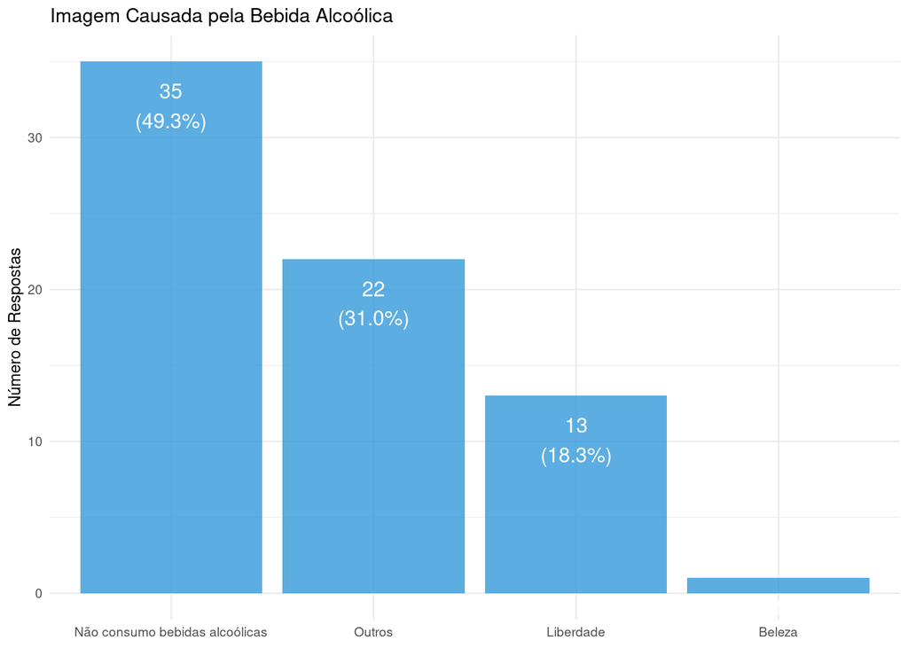

  ```r
  # 3. GRÁFICO
  ggplot(tabela_imagem, aes(x = reorder(Imagem, -Quantidade), y = Quantidade)) +
    geom_bar(stat = "identity", fill = "#3498DB", alpha = 0.8) +
    geom_text(aes(label = paste0(Quantidade, "\n(", Percentual, ")")), vjust = 1.5, color = "white", size = 4) +
    labs(title = "Imagem Causada pela Bebida Alcoólica", x = NULL, y = "Número de Respostas") +
    theme_minimal(base_size = 9)
  ```

- Tipo de bebida que ingere

  ```r
  # 1. CÁLCULO
  tabela_tipo <- dados_brutos %>%
    count(TipoQueToma, sort = TRUE) %>%
    mutate(Percentual = scales::percent(n / sum(n), accuracy = 0.1)) %>%
    rename(`Tipo de Bebida` = TipoQueToma, Quantidade = n)

  # 2. TABELA
  knitr::kable(tabela_tipo, caption = "Qual tipo de bebida alcoólica costuma tomar?")
  ```

  Qual tipo de bebida alcoólica costuma tomar?

  | Tipo de Bebida | Quantidade | Percentual |
  | --- | --- | --- |
  | Não consumo bebidas alcoólicas | 37 | 52.1% |
  | “ICE” | 13 | 18.3% |
  | Cerveja | 12 | 16.9% |
  | Outros | 5 | 7.0% |
  | Vinho | 4 | 5.6% |

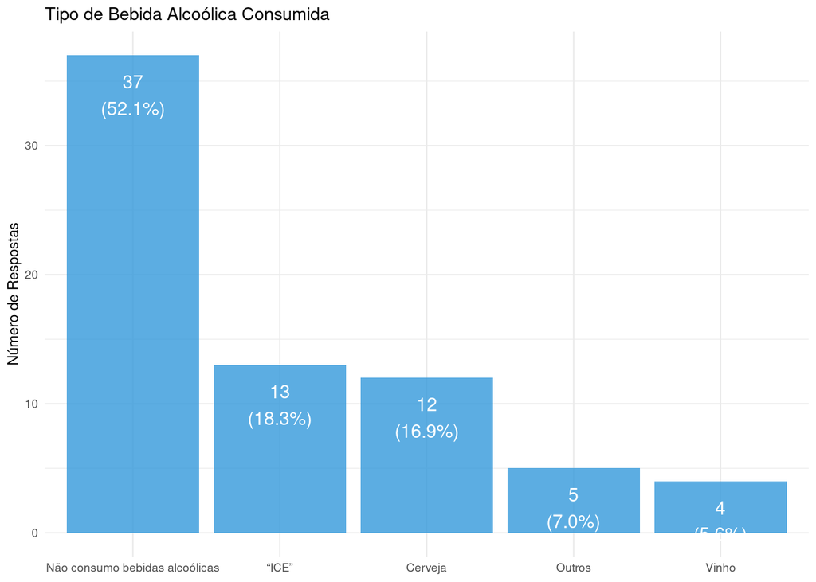

  ```r
  # 3. GRÁFICO
  ggplot(tabela_tipo, aes(x = reorder(`Tipo de Bebida`, -Quantidade), y = Quantidade)) +
    geom_bar(stat = "identity", fill = "#3498DB", alpha = 0.8) +
    geom_text(aes(label = paste0(Quantidade, "\n(", Percentual, ")")), vjust = 1.5, color = "white", size = 4) +
    labs(title = "Tipo de Bebida Alcoólica Consumida", x = NULL, y = "Número de Respostas") +
    theme_minimal(base_size = 9)
  ```

- Vexame por causa da bebida

  ```r
  # 1. CÁLCULO
  tabela_vexame <- dados_brutos %>%
    count(DeuVexamePorCausaDaBebida, sort = TRUE) %>%
    mutate(Percentual = scales::percent(n / sum(n), accuracy = 0.1)) %>%
    rename(Resposta = DeuVexamePorCausaDaBebida, Quantidade = n)

  # 2. TABELA
  knitr::kable(tabela_vexame, caption = "Já deu algum vexame por causa da bebida?")
  ```

  Já deu algum vexame por causa da bebida?

  | Resposta | Quantidade | Percentual |
  | --- | --- | --- |
  | Não | 57 | 80.3% |
  | Sim | 14 | 19.7% |

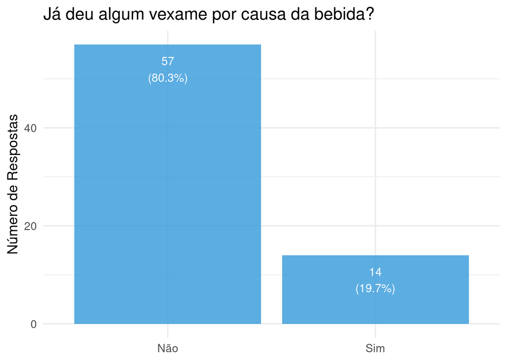

  ```r
  # 3. GRÁFICO
  ggplot(tabela_vexame, aes(x = reorder(Resposta, -Quantidade), y = Quantidade)) +
    geom_bar(stat = "identity", fill = "#3498DB", alpha = 0.8) +
    geom_text(aes(label = paste0(Quantidade, "\n(", Percentual, ")")), vjust = 1.5, color = "white", size = 4) +
    labs(title = "Já deu algum vexame por causa da bebida?", x = NULL, y = "Número de Respostas") +
    theme_minimal(base_size = 14)
  ```

- Sofreu acidente de carro por causa da bebida

  ```r
  # 1. CÁLCULO
  tabela_acidente <- dados_brutos %>%
    count(SofreuAcidenteDeCarroPorCausaDaBebida, sort = TRUE) %>%
    mutate(Percentual = scales::percent(n / sum(n), accuracy = 0.1)) %>%
    rename(Resposta = SofreuAcidenteDeCarroPorCausaDaBebida, Quantidade = n)

  # 2. TABELA
  knitr::kable(tabela_acidente, caption = "Já sofreu algum acidente de carro por causa da bebida?")
  ```

  Já sofreu algum acidente de carro por causa da bebida?

  | Resposta | Quantidade | Percentual |
  | --- | --- | --- |
  | Não | 71 | 100.0% |

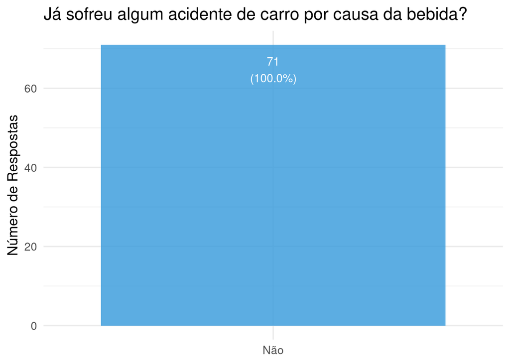

  ```r
  # 3. GRÁFICO
  ggplot(tabela_acidente, aes(x = reorder(Resposta, -Quantidade), y = Quantidade)) +
    geom_bar(stat = "identity", fill = "#3498DB", alpha = 0.8) +
    geom_text(aes(label = paste0(Quantidade, "\n(", Percentual, ")")), vjust = 1.5, color = "white", size = 4) +
    labs(title = "Já sofreu algum acidente de carro por causa da bebida?", x = NULL, y = "Número de Respostas") +
    theme_minimal(base_size = 14)
  ```

- Dirigiu sob efeito de álcool

  ```r
  # 1. CÁLCULO
  tabela_dirigiu <- dados_brutos %>%
    count(DirigiuSobEfeitoDoAlcool, sort = TRUE) %>%
    mutate(Percentual = scales::percent(n / sum(n), accuracy = 0.1)) %>%
    rename(Resposta = DirigiuSobEfeitoDoAlcool, Quantidade = n)

  # 2. TABELA
  knitr::kable(tabela_dirigiu, caption = "Já dirigiu sobre efeito do álcool?")
  ```

  Já dirigiu sobre efeito do álcool?

  | Resposta | Quantidade | Percentual |
  | --- | --- | --- |
  | Não | 66 | 93.0% |
  | Sim | 5 | 7.0% |

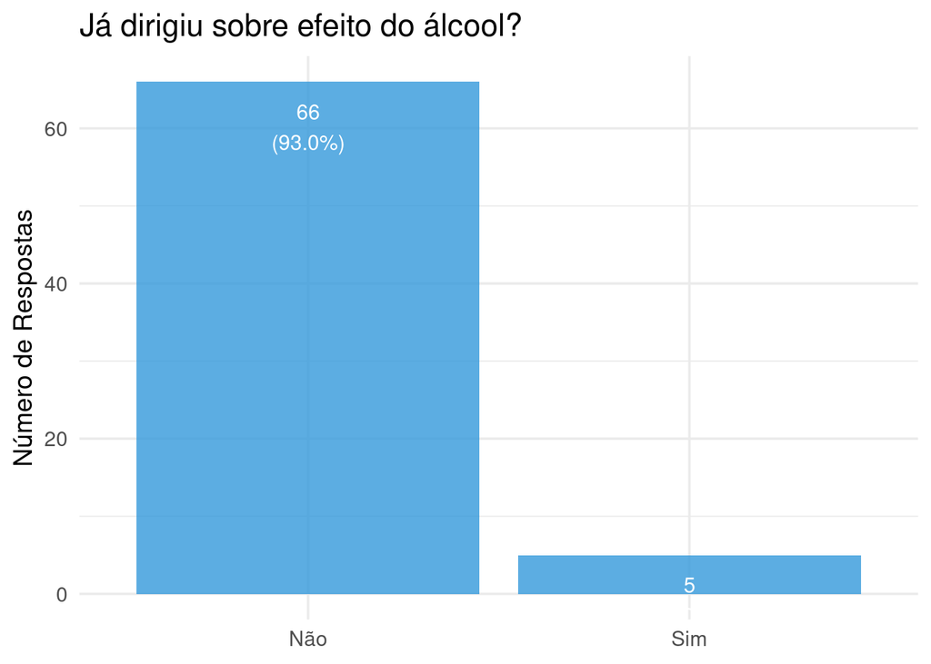

  ```r
  # 3. GRÁFICO
  ggplot(tabela_dirigiu, aes(x = reorder(Resposta, -Quantidade), y = Quantidade)) +
    geom_bar(stat = "identity", fill = "#3498DB", alpha = 0.8) +
    geom_text(aes(label = paste0(Quantidade, "\n(", Percentual, ")")), vjust = 1.5, color = "white", size = 4) +
    labs(title = "Já dirigiu sobre efeito do álcool?", x = NULL, y = "Número de Respostas") +
    theme_minimal(base_size = 14)
  ```

- Pegou carona com alguém sob efeito de álcool

  ```r
  # 1. CÁLCULO
  tabela_carona <- dados_brutos %>%
    count(PegouCaronaComAlguemSobEfeitoDaBebida, sort = TRUE) %>%
    mutate(Percentual = scales::percent(n / sum(n), accuracy = 0.1)) %>%
    rename(Resposta = PegouCaronaComAlguemSobEfeitoDaBebida, Quantidade = n)

  # 2. TABELA
  knitr::kable(tabela_carona, caption = "Já pegou carona com alguém que dirigiu sobre efeito do álcool?")
  ```

  Já pegou carona com alguém que dirigiu sobre efeito do álcool?

  | Resposta | Quantidade | Percentual |
  | --- | --- | --- |
  | Sim | 39 | 54.9% |
  | Não | 32 | 45.1% |

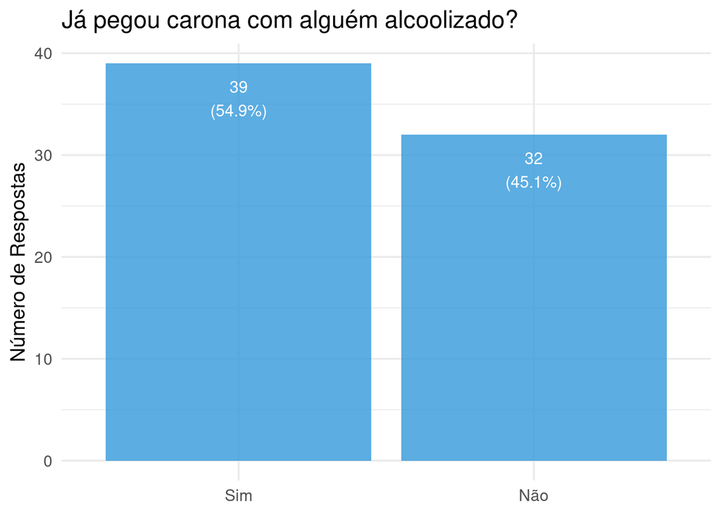

  ```r
  # 3. GRÁFICO
  ggplot(tabela_carona, aes(x = reorder(Resposta, -Quantidade), y = Quantidade)) +
    geom_bar(stat = "identity", fill = "#3498DB", alpha = 0.8) +
    geom_text(aes(label = paste0(Quantidade, "\n(", Percentual, ")")), vjust = 1.5, color = "white", size = 4) +
    labs(title = "Já pegou carona com alguém alcoolizado?", x = NULL, y = "Número de Respostas") +
    theme_minimal(base_size = 14)
  ```

- Pais consomem bebida alcoólica

  ```r
  # 1. CÁLCULO
  tabela_pais <- dados_brutos %>%
    count(PaisConsomem, sort = TRUE) %>%
    mutate(Percentual = scales::percent(n / sum(n), accuracy = 0.1)) %>%
    rename(Resposta = PaisConsomem, Quantidade = n)

  # 2. TABELA
  knitr::kable(tabela_pais, caption = "Seus pais consomem bebida alcoólica?")
  ```

  Seus pais consomem bebida alcoólica?

  | Resposta | Quantidade | Percentual |
  | --- | --- | --- |
  | Sim | 37 | 52.1% |
  | Não | 34 | 47.9% |

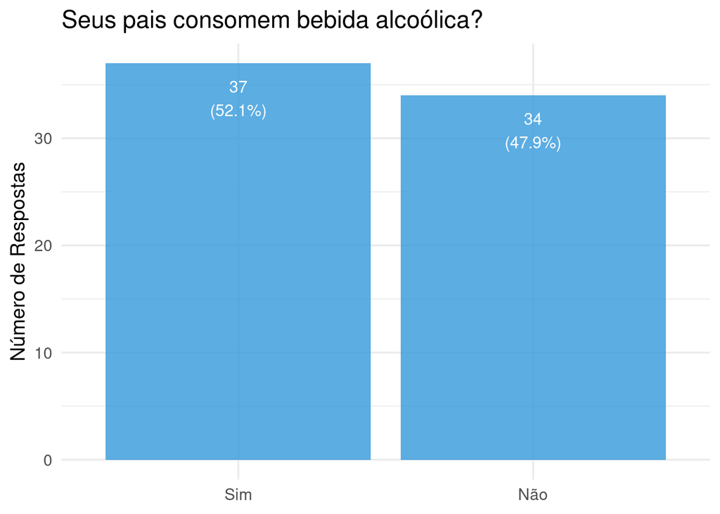

  ```r
  # 3. GRÁFICO
  ggplot(tabela_pais, aes(x = reorder(Resposta, -Quantidade), y = Quantidade)) +
    geom_bar(stat = "identity", fill = "#3498DB", alpha = 0.8) +
    geom_text(aes(label = paste0(Quantidade, "\n(", Percentual, ")")), vjust = 1.5, color = "white", size = 4) +
    labs(title = "Seus pais consomem bebida alcoólica?", x = NULL, y = "Número de Respostas") +
    theme_minimal(base_size = 14)
  ```

- Conhece alguém próximo que sofreu acidente por causa da bebida

  ```r
  # 1. CÁLCULO
  tabela_conhecido <- dados_brutos %>%
    count(ConheceAlguemQueSeAcidentouPorCausaDaBebida, sort = TRUE) %>%
    mutate(Percentual = scales::percent(n / sum(n), accuracy = 0.1)) %>%
    rename(Resposta = ConheceAlguemQueSeAcidentouPorCausaDaBebida, Quantidade = n)

  # 2. TABELA
  knitr::kable(tabela_conhecido, caption = "Conhece alguém próximo que sofreu um acidente por causa de bebida?")
  ```

  Conhece alguém próximo que sofreu um acidente por causa de bebida?

  | Resposta | Quantidade | Percentual |
  | --- | --- | --- |
  | Sim | 42 | 59.2% |
  | Não | 29 | 40.8% |

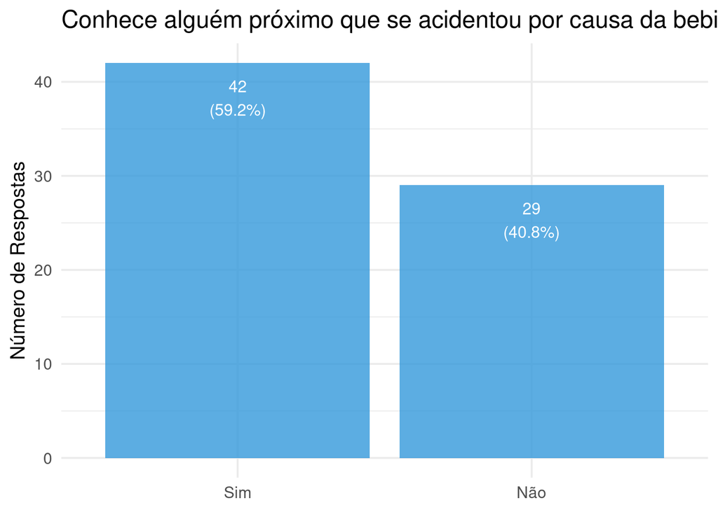

  ```r
  # 3. GRÁFICO
  ggplot(tabela_conhecido, aes(x = reorder(Resposta, -Quantidade), y = Quantidade)) +
    geom_bar(stat = "identity", fill = "#3498DB", alpha = 0.8) +
    geom_text(aes(label = paste0(Quantidade, "\n(", Percentual, ")")), vjust = 1.5, color = "white", size = 4) +
    labs(title = "Conhece alguém próximo que se acidentou por causa da bebida?", x = NULL, y = "Número de Respostas") +
    theme_minimal(base_size = 14)
  ```

#### Cruzando os dados em cinco eixos principais

  Eixo 01: Perfil de consumo (Demografia vs. consumo)
- Sexo vs. Respondente ingere

  Analisamos se a proporção de consumo de álcool muda à depender do gênero do respondente

  ```r
  # CÁLCULO DE CRUZAMENTO E PERCENTUAIS
  tabela_sexo_vs_consumo <- dados_brutos %>% filter(!is.na(Sexo) & !is.na(RespondenteIngere)) %>%
    count(Sexo, RespondenteIngere) %>% group_by(Sexo) %>%
    mutate(
      Percentual = scales::percent(n / sum(n), accuracy=0.1)
    ) %>% ungroup() %>% rename(Quantidade = n)

  # TESTE ESTATÍSTICO (QUI-QUADRADO)
  tabela_contigencia <- dados_brutos %>%
    count(Sexo, RespondenteIngere) %>%
    tidyr::pivot_wider(names_from = RespondenteIngere, values_from = n, values_fill = 0)

  teste_qui_quadrado <- chisq.test(tabela_contigencia[, -1])
  cat("=== TESTE QUI-QUADRADO ===")
  ```

  ```
  ## === TESTE QUI-QUADRADO ===
  ```

  ```r
  print(teste_qui_quadrado)
  ```

  ```
  ##
  ##  Pearson's Chi-squared test
  ##
  ## data:  tabela_contigencia[, -1]
  ## X-squared = 0.80251, df = 2, p-value = 0.6695
  ```

  ```r
  cat("\n\n")
  ```

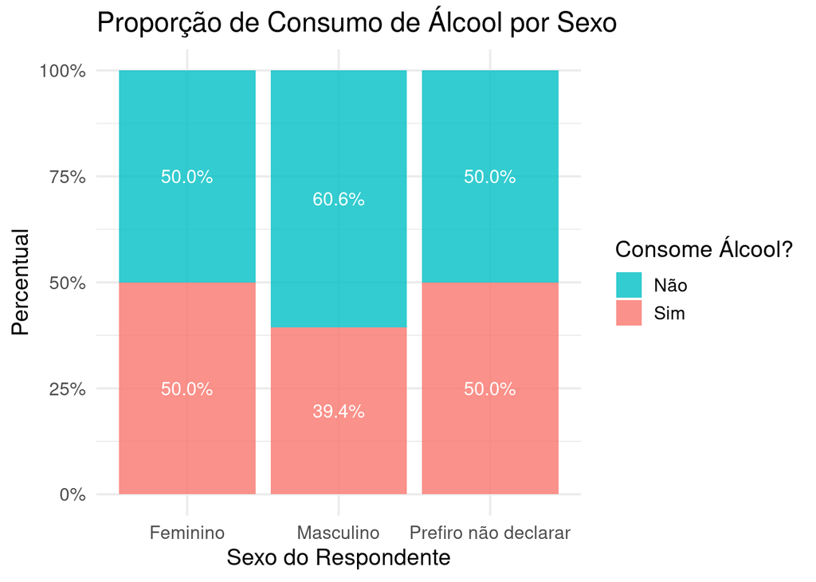

  ```r
  # GRÁFICO
  ggplot(tabela_sexo_vs_consumo, aes(x = Sexo, y = Quantidade, fill = RespondenteIngere)) +
    # position="fill" cria as barras de 100%
    geom_bar(stat = "identity", position = "fill", alpha = 0.8) +
    # Adiciona os rótulos de percentual no meio de cada segmento da barra
    geom_text(
      aes(label = Percentual),
      position = position_fill(vjust = 0.5), # Centraliza o texto no segmento
      color = "white",
      size = 4
    ) +
    scale_fill_discrete(direction = -1) +
    scale_y_continuous(labels = scales::percent) +
    labs(
      title = "Proporção de Consumo de Álcool por Sexo",
      x = "Sexo do Respondente",
      y = "Percentual",
      fill = "Consome Álcool?" # Muda o título da legenda
    ) +
    theme_minimal(base_size = 14)
  ```

  ```r
  # TABELA
  cat("\n\n### Tabela de Cruzamento: Sexo vs. Consumo de Álcool\n")
  ```

  ```
  ##
  ##
  ## ### Tabela de Cruzamento: Sexo vs. Consumo de Álcool
  ```

  ```r
  knitr::kable(
    tabela_sexo_vs_consumo,
    caption = "Tabela de cruzamento mostrando a quantidade e o percentual de consumo por sexo."
  )
  ```

  Tabela de cruzamento mostrando a quantidade e o percentual de consumo por sexo.

  | Sexo | RespondenteIngere | Quantidade | Percentual |
  | --- | --- | --- | --- |
  | Feminino | Não | 18 | 50.0% |
  | Feminino | Sim | 18 | 50.0% |
  | Masculino | Não | 20 | 60.6% |
  | Masculino | Sim | 13 | 39.4% |
  | Prefiro não declarar | Não | 1 | 50.0% |
  | Prefiro não declarar | Sim | 1 | 50.0% |

- Religião vs. Respondente ingere

  Analisamos se a proporção de consumo muda conforme a religião do respondente

  ```r
  # CÁLCULO DE CRUZAMENTO E PERCENTUAIS
  tabela_religiao_vs_consumo <- dados_brutos %>% filter(!is.na(Religiao) & !is.na(RespondenteIngere)) %>%
    count(Religiao, RespondenteIngere) %>% group_by(Religiao) %>%
    mutate(
      Percentual = scales::percent(n / sum(n), accuracy=0.1)
    ) %>% ungroup() %>% rename(Quantidade = n)

  # TESTE ESTATÍSTICO (QUI-QUADRADO)
  tabela_contigencia <- dados_brutos %>%
    count(Religiao, RespondenteIngere) %>%
    tidyr::pivot_wider(names_from = RespondenteIngere, values_from = n, values_fill = 0)

  teste_qui_quadrado <- chisq.test(tabela_contigencia[, -1])
  cat("=== TESTE QUI-QUADRADO ===")
  ```

  ```
  ## === TESTE QUI-QUADRADO ===
  ```

  ```r
  print(teste_qui_quadrado)
  ```

  ```
  ##
  ##  Pearson's Chi-squared test
  ##
  ## data:  tabela_contigencia[, -1]
  ## X-squared = 5.5639, df = 2, p-value = 0.06192
  ```

  ```r
  cat("\n\n")
  ```

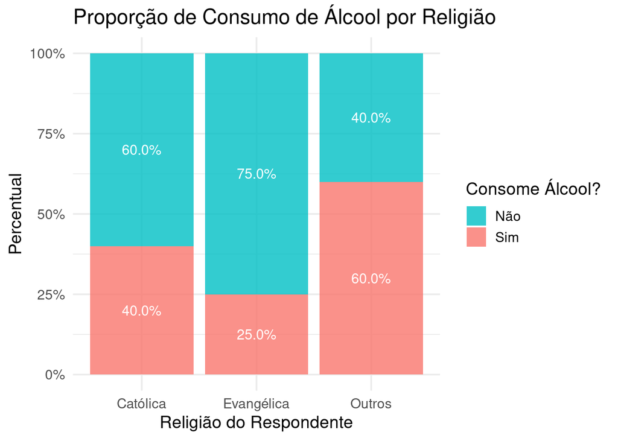

  ```r
  # GRÁFICO
  ggplot(tabela_religiao_vs_consumo, aes(x = Religiao, y = Quantidade, fill = RespondenteIngere)) +
    # position="fill" cria as barras de 100%
    geom_bar(stat = "identity", position = "fill", alpha = 0.8) +
    # Adiciona os rótulos de percentual no meio de cada segmento da barra
    geom_text(
      aes(label = Percentual),
      position = position_fill(vjust = 0.5), # Centraliza o texto no segmento
      color = "white",
      size = 4
    ) +
    scale_fill_discrete(direction = -1) +
    scale_y_continuous(labels = scales::percent) +
    labs(
      title = "Proporção de Consumo de Álcool por Religião",
      x = "Religião do Respondente",
      y = "Percentual",
      fill = "Consome Álcool?" # Muda o título da legenda
    ) +
    theme_minimal(base_size = 14)
  ```

  ```r
  # TABELA
  cat("\n\n### Tabela de Cruzamento: Religião vs. Consumo de Álcool\n")
  ```

  ```
  ##
  ##
  ## ### Tabela de Cruzamento: Religião vs. Consumo de Álcool
  ```

  ```r
  knitr::kable(
    tabela_religiao_vs_consumo,
    caption = "Tabela de cruzamento mostrando a quantidade e o percentual de consumo por religião."
  )
  ```

  Tabela de cruzamento mostrando a quantidade e o percentual de consumo por religião.

  | Religiao | RespondenteIngere | Quantidade | Percentual |
  | --- | --- | --- | --- |
  | Católica | Não | 15 | 60.0% |
  | Católica | Sim | 10 | 40.0% |
  | Evangélica | Não | 12 | 75.0% |
  | Evangélica | Sim | 4 | 25.0% |
  | Outros | Não | 12 | 40.0% |
  | Outros | Sim | 18 | 60.0% |

- Pais consomem vs. Respondente ingere

  Verificamos se o fato dos pais do respondente consumirem ou não bebida alcoólica interfere em seu comportamento

  ```r
  # CÁLCULO DE CRUZAMENTO E PERCENTUAIS
  tabela_paisConsomem_vs_consumo <- dados_brutos %>% filter(!is.na(PaisConsomem) & !is.na(RespondenteIngere)) %>%
    count(PaisConsomem, RespondenteIngere) %>% group_by(PaisConsomem) %>%
    mutate(
      Percentual = scales::percent(n / sum(n), accuracy=0.1)
    ) %>% ungroup() %>% rename(Quantidade = n)

  # TESTE ESTATÍSTICO (QUI-QUADRADO)
  tabela_contigencia <- dados_brutos %>%
    count(PaisConsomem, RespondenteIngere) %>%
    tidyr::pivot_wider(names_from = RespondenteIngere, values_from = n, values_fill = 0)

  teste_qui_quadrado <- chisq.test(tabela_contigencia[, -1])
  cat("=== TESTE QUI-QUADRADO ===")
  ```

  ```
  ## === TESTE QUI-QUADRADO ===
  ```

  ```r
  print(teste_qui_quadrado)
  ```

  ```
  ##
  ##  Pearson's Chi-squared test with Yates' continuity correction
  ##
  ## data:  tabela_contigencia[, -1]
  ## X-squared = 3.3335, df = 1, p-value = 0.06788
  ```

  ```r
  cat("\n\n")
  ```

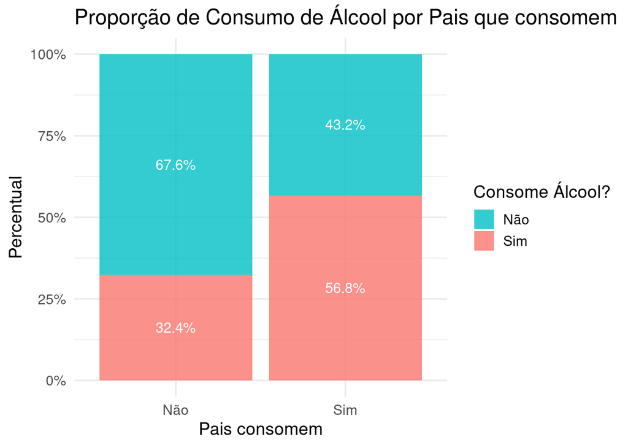

  ```r
  # GRÁFICO
  ggplot(tabela_paisConsomem_vs_consumo, aes(x = PaisConsomem, y = Quantidade, fill = RespondenteIngere)) +
    # position="fill" cria as barras de 100%
    geom_bar(stat = "identity", position = "fill", alpha = 0.8) +
    # Adiciona os rótulos de percentual no meio de cada segmento da barra
    geom_text(
      aes(label = Percentual),
      position = position_fill(vjust = 0.5), # Centraliza o texto no segmento
      color = "white",
      size = 4
    ) +
    scale_fill_discrete(direction = -1) +
    scale_y_continuous(labels = scales::percent) +
    labs(
      title = "Proporção de Consumo de Álcool por Pais que consomem",
      x = "Pais consomem",
      y = "Percentual",
      fill = "Consome Álcool?" # Muda o título da legenda
    ) +
    theme_minimal(base_size = 14)
  ```

  ```r
  # TABELA
  cat("\n\n### Tabela de Cruzamento: Pais consomem vs. Consumo de Álcool\n")
  ```

  ```
  ##
  ##
  ## ### Tabela de Cruzamento: Pais consomem vs. Consumo de Álcool
  ```

  ```r
  knitr::kable(
    tabela_paisConsomem_vs_consumo,
    caption = "Tabela de cruzamento mostrando a quantidade e o percentual de consumo por pais que consomem"
  )
  ```

  Tabela de cruzamento mostrando a quantidade e o percentual de consumo por pais que consomem

  | PaisConsomem | RespondenteIngere | Quantidade | Percentual |
  | --- | --- | --- | --- |
  | Não | Não | 23 | 67.6% |
  | Não | Sim | 11 | 32.4% |
  | Sim | Não | 16 | 43.2% |
  | Sim | Sim | 21 | 56.8% |

- Renda familiar vs. Respondente ingere

  Analisamos se a renda familiar do respondente interfere em seu comportamento em relaçao as bebidas alcoólicas

```r
# CÁLCULO DE CRUZAMENTO E PERCENTUAIS
tabela_renda_vs_consumo <- dados_brutos %>% filter(!is.na(RendaFamiliar) & !is.na(RespondenteIngere)) %>%
  count(RendaFamiliar, RespondenteIngere) %>% group_by(RendaFamiliar) %>%
  mutate(
    Percentual = scales::percent(n / sum(n), accuracy=0.1)
  ) %>% ungroup() %>% rename(Quantidade = n)

# TESTE ESTATÍSTICO (QUI-QUADRADO)
tabela_contigencia <- dados_brutos %>%
  count(RendaFamiliar, RespondenteIngere) %>%
  tidyr::pivot_wider(names_from = RespondenteIngere, values_from = n, values_fill = 0)

teste_qui_quadrado <- chisq.test(tabela_contigencia[, -1])
cat("=== TESTE QUI-QUADRADO ===")
```

```
## === TESTE QUI-QUADRADO ===
```

```r
print(teste_qui_quadrado)
```

```
##
##  Pearson's Chi-squared test
##
## data:  tabela_contigencia[, -1]
## X-squared = 1.8872, df = 4, p-value = 0.7565
```

```r
cat("\n\n")
```

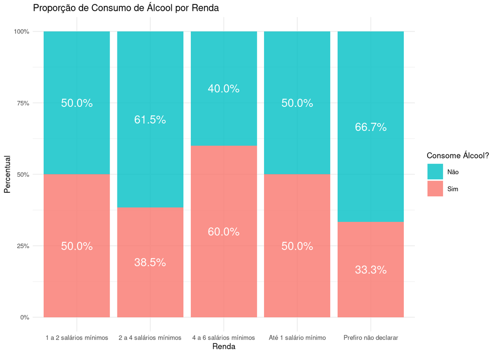

```r
# GRÁFICO
ggplot(tabela_renda_vs_consumo, aes(x = RendaFamiliar, y = Quantidade, fill = RespondenteIngere)) +
  # position="fill" cria as barras de 100%
  geom_bar(stat = "identity", position = "fill", alpha = 0.8) +
  # Adiciona os rótulos de percentual no meio de cada segmento da barra
  geom_text(
    aes(label = Percentual),
    position = position_fill(vjust = 0.5), # Centraliza o texto no segmento
    color = "white",
    size = 4
  ) +
  scale_fill_discrete(direction = -1) +
  scale_y_continuous(labels = scales::percent) +
  labs(
    title = "Proporção de Consumo de Álcool por Renda",
    x = "Renda",
    y = "Percentual",
    fill = "Consome Álcool?" # Muda o título da legenda
  ) +
  theme_minimal(base_size = 8)
```

```r
# TABELA
cat("\n\n### Tabela de Cruzamento: Renda vs. Consumo de Álcool\n")
```

```
##
##
## ### Tabela de Cruzamento: Renda vs. Consumo de Álcool
```

```r
knitr::kable(
  tabela_renda_vs_consumo,
  caption = "Tabela de cruzamento mostrando a quantidade e o percentual de consumo por renda"
)
```

Tabela de cruzamento mostrando a quantidade e o percentual de consumo por renda

| RendaFamiliar | RespondenteIngere | Quantidade | Percentual |
| --- | --- | --- | --- |
| 1 a 2 salários mínimos | Não | 9 | 50.0% |
| 1 a 2 salários mínimos | Sim | 9 | 50.0% |
| 2 a 4 salários mínimos | Não | 8 | 61.5% |
| 2 a 4 salários mínimos | Sim | 5 | 38.5% |
| 4 a 6 salários mínimos | Não | 2 | 40.0% |
| 4 a 6 salários mínimos | Sim | 3 | 60.0% |
| Até 1 salário mínimo | Não | 10 | 50.0% |
| Até 1 salário mínimo | Sim | 10 | 50.0% |
| Prefiro não declarar | Não | 10 | 66.7% |
| Prefiro não declarar | Sim | 5 | 33.3% |

- Trabalha vs. Respondente ingere

  É analisada se a situação empregatícia do respondente interfere no comportamento em relação a beber ou não álcool.

  ```r
  # CÁLCULO DE CRUZAMENTO E PERCENTUAIS
  tabela_trabalha_vs_consumo <- dados_brutos %>% filter(!is.na(Trabalha) & !is.na(RespondenteIngere)) %>%
    count(Trabalha, RespondenteIngere) %>% group_by(Trabalha) %>%
    mutate(
      Percentual = scales::percent(n / sum(n), accuracy=0.1)
    ) %>% ungroup() %>% rename(Quantidade = n)

  # TESTE ESTATÍSTICO (QUI-QUADRADO)
  tabela_contigencia <- dados_brutos %>%
    count(Trabalha, RespondenteIngere) %>%
    tidyr::pivot_wider(names_from = RespondenteIngere, values_from = n, values_fill = 0)

  teste_qui_quadrado <- chisq.test(tabela_contigencia[, -1])
  cat("=== TESTE QUI-QUADRADO ===")
  ```

  ```
  ## === TESTE QUI-QUADRADO ===
  ```

  ```r
  print(teste_qui_quadrado)
  ```

  ```
  ##
  ##  Pearson's Chi-squared test with Yates' continuity correction
  ##
  ## data:  tabela_contigencia[, -1]
  ## X-squared = 0.72023, df = 1, p-value = 0.3961
  ```

  ```r
  cat("\n\n")
  ```

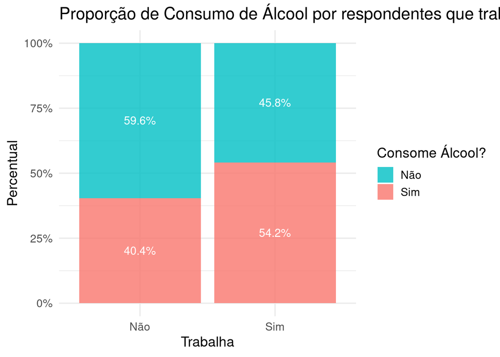

  ```r
  # GRÁFICO
  ggplot(tabela_trabalha_vs_consumo, aes(x = Trabalha, y = Quantidade, fill = RespondenteIngere)) +
    # position="fill" cria as barras de 100%
    geom_bar(stat = "identity", position = "fill", alpha = 0.8) +
    # Adiciona os rótulos de percentual no meio de cada segmento da barra
    geom_text(
      aes(label = Percentual),
      position = position_fill(vjust = 0.5), # Centraliza o texto no segmento
      color = "white",
      size = 4
    ) +
    scale_fill_discrete(direction = -1) +
    scale_y_continuous(labels = scales::percent) +
    labs(
      title = "Proporção de Consumo de Álcool por respondentes que trabalham",
      x = "Trabalha",
      y = "Percentual",
      fill = "Consome Álcool?" # Muda o título da legenda
    ) +
    theme_minimal(base_size = 14)
  ```

  ```r
  # TABELA
  cat("\n\n### Tabela de Cruzamento: Trabalha vs. Consumo de Álcool\n")
  ```

  ```
  ##
  ##
  ## ### Tabela de Cruzamento: Trabalha vs. Consumo de Álcool
  ```

  ```r
  knitr::kable(
    tabela_trabalha_vs_consumo,
    caption = "Tabela de cruzamento mostrando a quantidade e o percentual de consumo por respondentes que trabalham."
  )
  ```

  Tabela de cruzamento mostrando a quantidade e o percentual de consumo por respondentes que trabalham.

  | Trabalha | RespondenteIngere | Quantidade | Percentual |
  | --- | --- | --- | --- |
  | Não | Não | 28 | 59.6% |
  | Não | Sim | 19 | 40.4% |
  | Sim | Não | 11 | 45.8% |
  | Sim | Sim | 13 | 54.2% |

Eixo 02: Padrão de consumo (Demografia vs. Comportamento)

- Sexo vs. Tipo que toma

  Verificamos a preferência por um tipo de bebida em relação ao gênero.

  ```r
  tabela_sexo_vs_tipo <- dados_brutos %>%
    filter(!is.na(Sexo) & !is.na(TipoQueToma)) %>%
    count(Sexo, TipoQueToma) %>%
    group_by(Sexo) %>%
    mutate(
      # Percentual NUMÉRICO: para a altura das barras e cálculos
      PercentualNumerico = n / sum(n),
      # Percentual em TEXTO: para os rótulos do gráfico e tabelas
      PercentualTexto = scales::percent(PercentualNumerico, accuracy = 0.1)
    ) %>%
    ungroup() %>%
    rename(Quantidade = n)

  tabela_contingencia <- dados_brutos %>%
    count(Sexo, TipoQueToma) %>%
    tidyr::pivot_wider(names_from = TipoQueToma, values_from = n, values_fill = 0)

  teste_qui_quadrado <- chisq.test(tabela_contingencia[, -1])
  cat("--- Teste Qui-Quadrado de Independência ---\n\n")
  ```

  ```
  ## --- Teste Qui-Quadrado de Independência ---
  ```

  ```r
  print(teste_qui_quadrado)
  ```

  ```
  ##
  ##  Pearson's Chi-squared test
  ##
  ## data:  tabela_contingencia[, -1]
  ## X-squared = 13.276, df = 8, p-value = 0.1027
  ```

  ```r
  cat("\n\n")
  ```

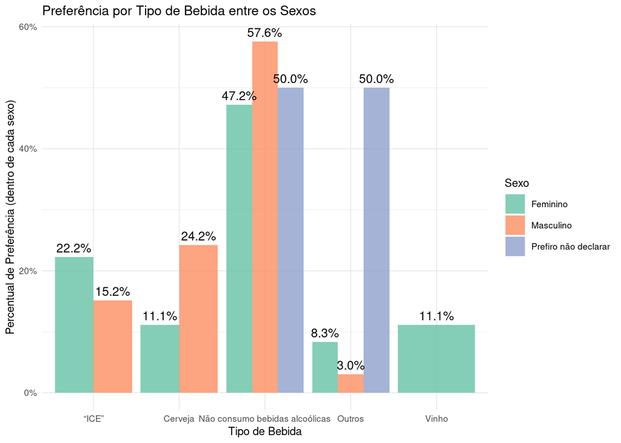

  ```r
  ggplot(tabela_sexo_vs_tipo, aes(x = TipoQueToma, y = PercentualNumerico, fill = Sexo)) +
    geom_bar(stat = "identity", position = "dodge", alpha = 0.8) +
    # O rótulo usa a coluna de TEXTO
    geom_text(
      aes(label = PercentualTexto),
      position = position_dodge(width = 0.9),
      vjust = -0.5,
      size = 3.5
    ) +

    scale_y_continuous(labels = scales::percent_format(accuracy = 1)) +
    scale_fill_brewer(palette = "Set2") +
    labs(
      title = "Preferência por Tipo de Bebida entre os Sexos",
      x = "Tipo de Bebida",
      y = "Percentual de Preferência (dentro de cada sexo)",
      fill = "Sexo"
    ) +
    theme_minimal(base_size = 9)
  ```

  ```r
  tabela_para_exibir <- tabela_sexo_vs_tipo %>%
    select(Sexo, `Tipo de Bebida` = TipoQueToma, Quantidade, Percentual = PercentualTexto)

  cat("\n\n### Tabela de Cruzamento: Sexo vs. Tipo de Bebida\n")
  ```

  ```
  ##
  ##
  ## ### Tabela de Cruzamento: Sexo vs. Tipo de Bebida
  ```

  ```r
  knitr::kable(
    tabela_para_exibir,
    caption = "Tabela de cruzamento mostrando a preferência por tipo de bebida dentro de cada sexo."
  )
  ```

  Tabela de cruzamento mostrando a preferência por tipo de bebida dentro de cada sexo.

  | Sexo | Tipo de Bebida | Quantidade | Percentual |
  | --- | --- | --- | --- |
  | Feminino | Cerveja | 4 | 11.1% |
  | Feminino | Não consumo bebidas alcoólicas | 17 | 47.2% |
  | Feminino | Outros | 3 | 8.3% |
  | Feminino | Vinho | 4 | 11.1% |
  | Feminino | “ICE” | 8 | 22.2% |
  | Masculino | Cerveja | 8 | 24.2% |
  | Masculino | Não consumo bebidas alcoólicas | 19 | 57.6% |
  | Masculino | Outros | 1 | 3.0% |
  | Masculino | “ICE” | 5 | 15.2% |
  | Prefiro não declarar | Não consumo bebidas alcoólicas | 1 | 50.0% |
  | Prefiro não declarar | Outros | 1 | 50.0% |

- Renda Familiar vs. Tipo que toma

  Análise da relaçao entre a renda familiar do respondente e o tipo de bebida que consome

  ```r
  tabela_renda_vs_tipo <- dados_brutos %>%
    filter(!is.na(RendaFamiliar) & !is.na(TipoQueToma)) %>%
    count(RendaFamiliar, TipoQueToma) %>%
    group_by(RendaFamiliar) %>%
    mutate(
      # Percentual NUMÉRICO: para a altura das barras e cálculos
      PercentualNumerico = n / sum(n),
      # Percentual em TEXTO: para os rótulos do gráfico e tabelas
      PercentualTexto = scales::percent(PercentualNumerico, accuracy = 0.1)
    ) %>%
    ungroup() %>%
    rename(Quantidade = n)

  tabela_contingencia <- dados_brutos %>%
    count(RendaFamiliar, TipoQueToma) %>%
    tidyr::pivot_wider(names_from = TipoQueToma, values_from = n, values_fill = 0)

  teste_qui_quadrado <- chisq.test(tabela_contingencia[, -1])
  cat("--- Teste Qui-Quadrado de Independência ---\n\n")
  ```

  ```
  ## --- Teste Qui-Quadrado de Independência ---
  ```

  ```r
  print(teste_qui_quadrado)
  ```

  ```
  ##
  ##  Pearson's Chi-squared test
  ##
  ## data:  tabela_contingencia[, -1]
  ## X-squared = 15.4, df = 16, p-value = 0.4956
  ```

  ```r
  cat("\n\n")
  ```

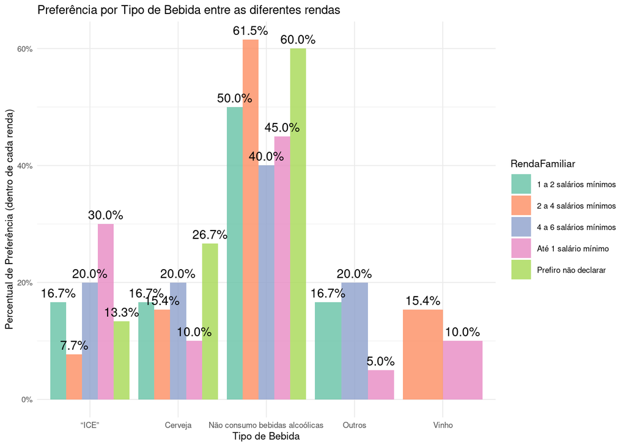

  ```r
  ggplot(tabela_renda_vs_tipo, aes(x = TipoQueToma, y = PercentualNumerico, fill = RendaFamiliar)) +
    geom_bar(stat = "identity", position = "dodge", alpha = 0.8) +
    # O rótulo usa a coluna de TEXTO
    geom_text(
      aes(label = PercentualTexto),
      position = position_dodge(width = 0.9),
      vjust = -0.5,
      size = 3.5
    ) +

    scale_y_continuous(labels = scales::percent_format(accuracy = 1)) +
    scale_fill_brewer(palette = "Set2") +
    labs(
      title = "Preferência por Tipo de Bebida entre as diferentes rendas",
      x = "Tipo de Bebida",
      y = "Percentual de Preferência (dentro de cada renda)",
      fill = "RendaFamiliar"
    ) +
    theme_minimal(base_size = 8)
  ```

  ```r
  tabela_para_exibir <- tabela_renda_vs_tipo %>%
    select(RendaFamiliar, `Tipo de Bebida` = TipoQueToma, Quantidade, Percentual = PercentualTexto)

  cat("\n\n### Tabela de Cruzamento: Renda Familiar vs. Tipo de Bebida\n")
  ```

  ```
  ##
  ##
  ## ### Tabela de Cruzamento: Renda Familiar vs. Tipo de Bebida
  ```

  ```r
  knitr::kable(
    tabela_para_exibir,
    caption = "Tabela de cruzamento mostrando a preferência por tipo de bebida dentro de cada nível de renda familiar"
  )
  ```

  Tabela de cruzamento mostrando a preferência por tipo de bebida dentro de cada nível de renda familiar

  | RendaFamiliar | Tipo de Bebida | Quantidade | Percentual |
  | --- | --- | --- | --- |
  | 1 a 2 salários mínimos | Cerveja | 3 | 16.7% |
  | 1 a 2 salários mínimos | Não consumo bebidas alcoólicas | 9 | 50.0% |
  | 1 a 2 salários mínimos | Outros | 3 | 16.7% |
  | 1 a 2 salários mínimos | “ICE” | 3 | 16.7% |
  | 2 a 4 salários mínimos | Cerveja | 2 | 15.4% |
  | 2 a 4 salários mínimos | Não consumo bebidas alcoólicas | 8 | 61.5% |
  | 2 a 4 salários mínimos | Vinho | 2 | 15.4% |
  | 2 a 4 salários mínimos | “ICE” | 1 | 7.7% |
  | 4 a 6 salários mínimos | Cerveja | 1 | 20.0% |
  | 4 a 6 salários mínimos | Não consumo bebidas alcoólicas | 2 | 40.0% |
  | 4 a 6 salários mínimos | Outros | 1 | 20.0% |
  | 4 a 6 salários mínimos | “ICE” | 1 | 20.0% |
  | Até 1 salário mínimo | Cerveja | 2 | 10.0% |
  | Até 1 salário mínimo | Não consumo bebidas alcoólicas | 9 | 45.0% |
  | Até 1 salário mínimo | Outros | 1 | 5.0% |
  | Até 1 salário mínimo | Vinho | 2 | 10.0% |
  | Até 1 salário mínimo | “ICE” | 6 | 30.0% |
  | Prefiro não declarar | Cerveja | 4 | 26.7% |
  | Prefiro não declarar | Não consumo bebidas alcoólicas | 9 | 60.0% |
  | Prefiro não declarar | “ICE” | 2 | 13.3% |

- Faixa etária vs. Frequência

  Analisamos se a faixa etária do respondente interfere em seu comportamento no consumo de bebidas alcoólicas

  ```r
  tabela_faixaEtaria_vs_frequencia <- dados_brutos %>%
    filter(!is.na(FaixaEtaria) & !is.na(Frequencia)) %>%
    count(FaixaEtaria, Frequencia) %>%
    group_by(FaixaEtaria) %>%
    mutate(
      # Percentual NUMÉRICO: para a altura das barras e cálculos
      PercentualNumerico = n / sum(n),
      # Percentual em TEXTO: para os rótulos do gráfico e tabelas
      PercentualTexto = scales::percent(PercentualNumerico, accuracy = 0.1)
    ) %>%
    ungroup() %>%
    rename(Quantidade = n)

  tabela_contingencia <- dados_brutos %>%
    count(FaixaEtaria, Frequencia) %>%
    tidyr::pivot_wider(names_from = Frequencia, values_from = n, values_fill = 0)

  teste_qui_quadrado <- chisq.test(tabela_contingencia[, -1])
  cat("--- Teste Qui-Quadrado de Independência ---\n\n")
  ```

  ```
  ## --- Teste Qui-Quadrado de Independência ---
  ```

  ```r
  print(teste_qui_quadrado)
  ```

  ```
  ##
  ##  Pearson's Chi-squared test
  ##
  ## data:  tabela_contingencia[, -1]
  ## X-squared = 14.441, df = 16, p-value = 0.5659
  ```

  ```r
  cat("\n\n")
  ```

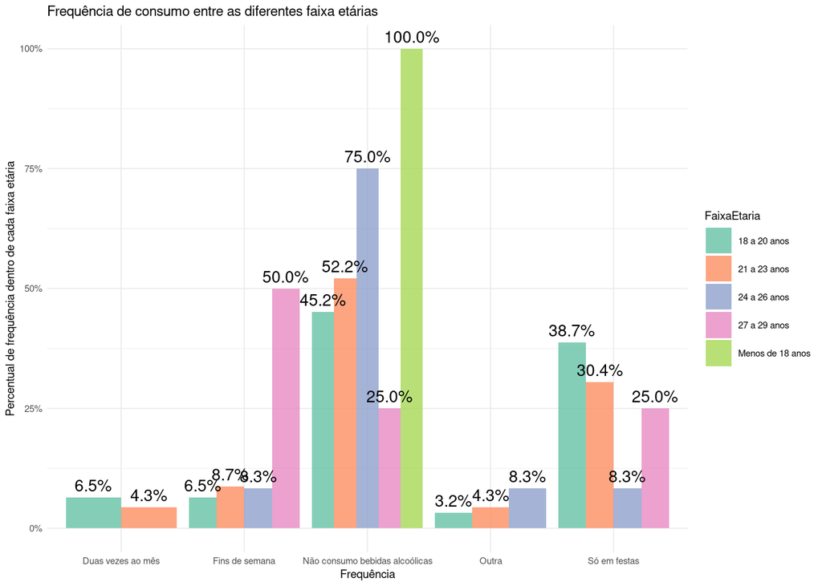

  ```r
  ggplot(tabela_faixaEtaria_vs_frequencia, aes(x = Frequencia, y = PercentualNumerico, fill = FaixaEtaria)) +
    geom_bar(stat = "identity", position = "dodge", alpha = 0.8) +
    # O rótulo usa a coluna de TEXTO
    geom_text(
      aes(label = PercentualTexto),
      position = position_dodge(width = 0.9),
      vjust = -0.5,
      size = 3.5
    ) +

    scale_y_continuous(labels = scales::percent_format(accuracy = 1)) +
    scale_fill_brewer(palette = "Set2") +
    labs(
      title = "Frequência de consumo entre as diferentes faixa etárias",
      x = "Frequência",
      y = "Percentual de frequência dentro de cada faixa etária",
      fill = "FaixaEtaria"
    ) +
    theme_minimal(base_size = 7)
  ```

  ```r
  tabela_para_exibir <- tabela_faixaEtaria_vs_frequencia %>%
    select(FaixaEtaria, `Frequencia` = Frequencia, Quantidade, Percentual = PercentualTexto)

  knitr::kable(
    tabela_para_exibir,
    caption = "Tabela de cruzamento mostrando a frequância de consumo em diferentes faixa etárias"
  )
  ```

  Tabela de cruzamento mostrando a frequância de consumo em diferentes faixa etárias

  | FaixaEtaria | Frequencia | Quantidade | Percentual |
  | --- | --- | --- | --- |
  | 18 a 20 anos | Duas vezes ao mês | 2 | 6.5% |
  | 18 a 20 anos | Fins de semana | 2 | 6.5% |
  | 18 a 20 anos | Não consumo bebidas alcoólicas | 14 | 45.2% |
  | 18 a 20 anos | Outra | 1 | 3.2% |
  | 18 a 20 anos | Só em festas | 12 | 38.7% |
  | 21 a 23 anos | Duas vezes ao mês | 1 | 4.3% |
  | 21 a 23 anos | Fins de semana | 2 | 8.7% |
  | 21 a 23 anos | Não consumo bebidas alcoólicas | 12 | 52.2% |
  | 21 a 23 anos | Outra | 1 | 4.3% |
  | 21 a 23 anos | Só em festas | 7 | 30.4% |
  | 24 a 26 anos | Fins de semana | 1 | 8.3% |
  | 24 a 26 anos | Não consumo bebidas alcoólicas | 9 | 75.0% |
  | 24 a 26 anos | Outra | 1 | 8.3% |
  | 24 a 26 anos | Só em festas | 1 | 8.3% |
  | 27 a 29 anos | Fins de semana | 2 | 50.0% |
  | 27 a 29 anos | Não consumo bebidas alcoólicas | 1 | 25.0% |
  | 27 a 29 anos | Só em festas | 1 | 25.0% |
  | Menos de 18 anos | Não consumo bebidas alcoólicas | 1 | 100.0% |

- Com quem mora vs. Frequência